# Assignment 8: Visualization - Making a bar race

*How to do it?*:

- Open the Rmarkdown file of this assignment (link) in Rstudio.
- Right under each **question**, insert a code chunk (you can use the hotkey `Ctrl + Alt + I` to add a code chunk) and code the solution for the question.
- `Knit` the rmarkdown file (hotkey: `Ctrl + Alt + K`) to export an html.
- Publish the html file to your Githiub Page.

*Submission*: Submit the link on Github of the assignment to Canvas

```r
library(ggplot2)
library(tidyverse)
library(knitr)
library(gganimate)
library(gifski)
library(lubridate)
library(knitr)
library(gapminder)
library(dplyr)
```

2. Using the `Adult Census Income` data, make an animation using `geom_bar` and `transition_states`.

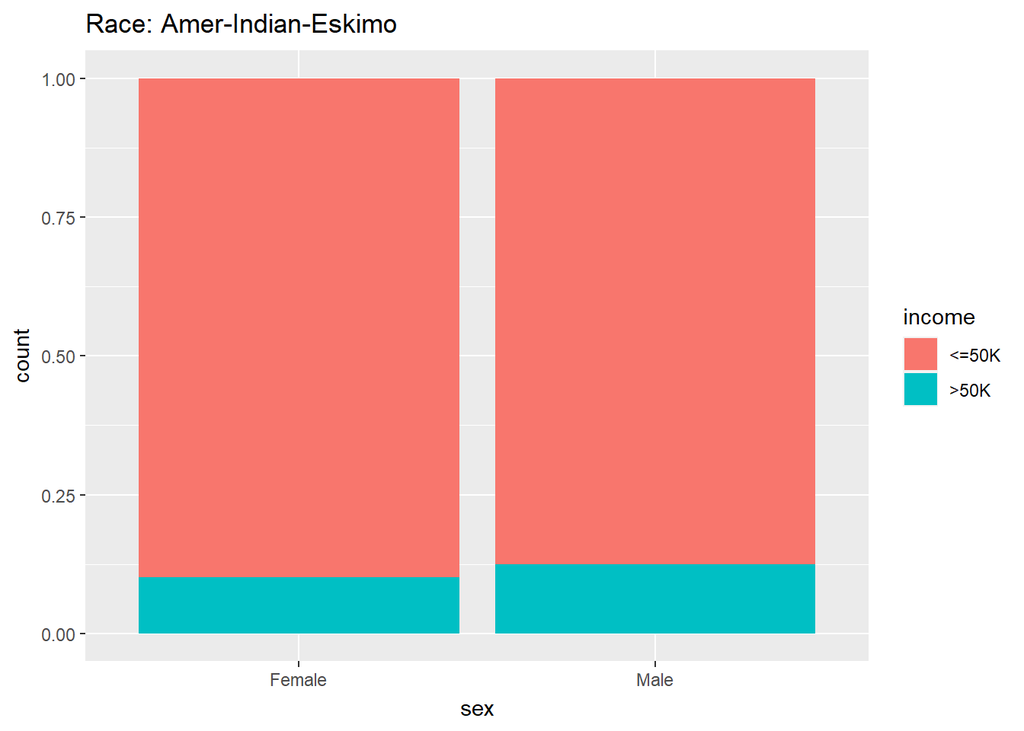

```r
df <- read.csv('adult_census.csv')
df %>% ggplot(aes(x = sex, fill=income))+
  geom_bar(position = 'fill')+
  transition_states(race)+
  labs(title = 'Race: {closest_state}')
```

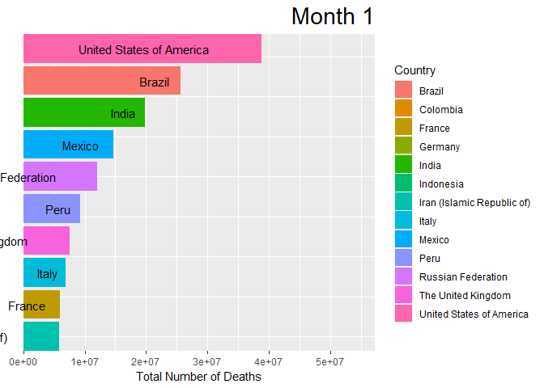

```r
dd <- read.csv('https://covid19.who.int/WHO-COVID-19-global-data.csv')
dd$month <- month(dd$Date_reported)
d1 <- dd %>% group_by(month, Country) %>% summarise(deaths = sum(Cumulative_deaths))
d2 <- d1 %>% group_by(month) %>% mutate(rank=rank(-deaths))
d3 <- d2 %>% filter(rank <= 10)

a1 <- d3 %>% ggplot(aes(x=rank, y=deaths, group=Country, fill=Country, label=Country)) + geom_col()+
    geom_text(aes(y = deaths, label = Country), hjust = 1.4)+
    coord_flip(clip = "off", expand = FALSE) +scale_x_reverse()+
    labs(title = 'Month {closest_state}', x='', y='Total Number of Deaths', fill='Country')+
    theme(plot.title = element_text(hjust = 1, size = 22),
          axis.ticks.y = element_blank(),
          axis.text.y  = element_blank()) +
    transition_states(month)+
    ease_aes("cubic-in-out")
animate(a1, nframes = 400)
```

4. Make a bar race using a dataset of your own interest. You may use the dataset that we use in class (https://covidtracking.com/data/download/all-states-history.csv) but you should make a different bar racev from ones in the slides.

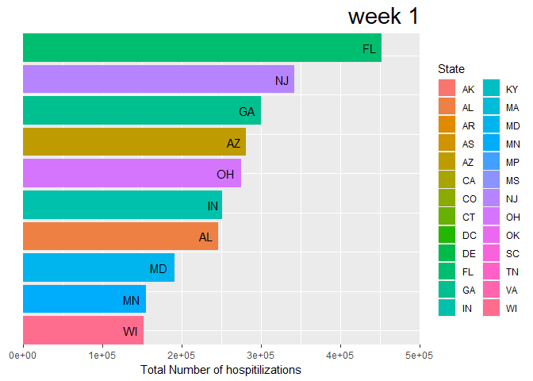

```r
df <- read.csv("all-states-history.csv")
df$week <- week(df$date)

d1 <- df %>% group_by(week, state) %>% summarise(hosp = sum(hospitalizedCumulative))
d2 <- d1 %>% group_by(week) %>% mutate(rank=rank(-hosp))
d3 <- d2 %>% filter(rank <= 10)

a1 <- d3 %>% ggplot(aes(x=rank, y=hosp, group=state, fill=state, label=state)) + geom_col()+
    geom_text(aes(y = hosp, label = state), hjust = 1.4)+
    coord_flip(clip = "off", expand = FALSE) +scale_x_reverse()+
    labs(title = 'week {closest_state}', x='', y='Total Number of hospitilizations', fill='State')+
    theme(plot.title = element_text(hjust = 1, size = 22),
          axis.ticks.y = element_blank(),
          axis.text.y  = element_blank()) +
    transition_states(week)+
    ease_aes("cubic-in-out")
animate(a1, nframes = 150)
```